# Course Project - Guess Mean Shiny Application

Silverio Neves

8 de Novembro de 2018

## Shiny Application Goal

The goal of the application is to have the maximum possible score guessing the mean using a tolerance.

- The user sets the guess mean and selects the tolerance.
- The computer generates randomly 10 numbers between 1 and 100
- The computer calculates the mean and compares to guess and tolerance
- To have no zero points the mean needs to be in the interval of the guess mean +/- tolerance.
- If the tolerance select was 1, the user obtain the maximum score of 100. 60 points for tolerance 5 and 20 points for tolerance 10.
- The computer attributes the user score based on tolerance selected

## User Interface

# Guess Game

Select your Guess (1<=mean<=100)

Select your tolerance

1 = 100 points

5 = 60 points

10 = 20 points

The user selects in the side panel the guess mean and tolerance to see results on the right with text and graphic.

## User Iterface

Your Guess was mean = 49 and tolerance = 10

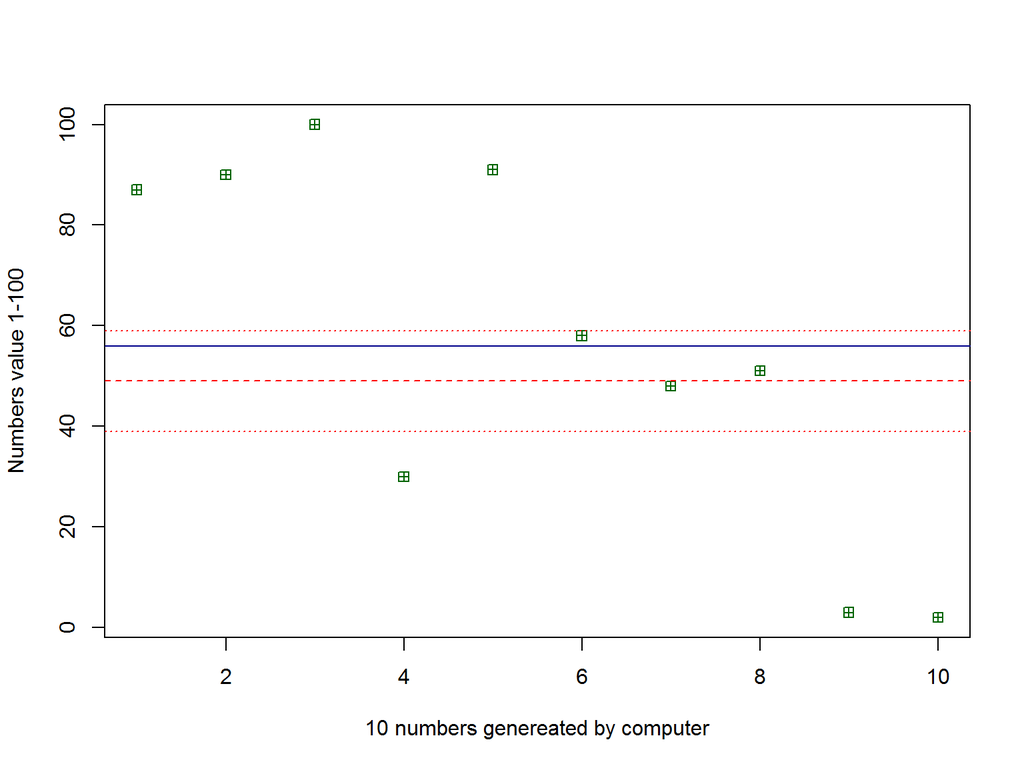

Your score is **`20`**

On the left side (side panel) appears all randomly generated numbers : `87, 90, 100, 30, 91, 58, 48, 51, 3, 2`

## Conclusions

This simple application can demonstrate how the Shiny is very suitable to do interactive graphics to present our results in conjugation with others stuffs to help in this work.